# Machine Learning & Lakes

The goal of this analysis is to see if we can predict the concentration of **chlorophyll *a*** (one of the major pigments involved in photosynthesis) in a lake. **Chlorophyll *a*** is a good indicator of the amount of phytoplankton in a lake or pond. These are the organisms that are sometimes responsible for a [harmful algal bloom](http://en.wikipedia.org/wiki/Algal_bloom). We’ll use a number of predictor variables that are commonly collected in surveys of lakes and ponds to try to predict chlorophyll *a*.

**Predictors:**

- Lake size
- Shoreline development index (*complexity of the shoreline*)
- Depth, maximum
- Day of the year (Julian)
- Total phosphorus
- Conductivity
- Alkalinity
- pH
- Secchi depth (i.e., water clarity)
- Dissolved oxygen
- Temperature

We’ll use a machine learning approach called a [Random Forest](http://en.wikipedia.org/wiki/Random_forest). This method is particularly good for situations where there are non-linear relationships in the data or you don’t want to assume a particular probability model.

We’ll be using data from the [U.S. Environmental Protection Agency (EPA) National Lake Assessment](http://water.epa.gov/type/lakes/lakessurvey_index.cfm). This data set includes over 1000 surveys of lakes and ponds across the US in 2007. A more detailed description of the data and direct URLs for downloading can be found [here](http://water.epa.gov/type/lakes/NLA_data.cfm).

# Download & import data

First, let’s get some data. We’ll use the package `RCurl` to download the raw .csv data directly from the EPA’s website. We’ll download data from three different data sets to get all of the variables that we want.

```r
library(RCurl)
# this contains pH, conductivity, total phosphorus, secchi depth, and chlorophyll a
URL <- "http://water.epa.gov/type/lakes/assessmonitor/lakessurvey/upload/NLA2007_WaterQuality_20091123.csv"
X <- getURL(URL, ssl.verifypeer = FALSE)
data_water_qual <- read.csv(textConnection(X))

# this contains lake size, shoreline development index, and maximum depth
URL <- "http://water.epa.gov/type/lakes/assessmonitor/lakessurvey/upload/NLA2007_SampledLakeInformation_20091113.csv"
X <- getURL(URL, ssl.verifypeer = FALSE)
data_lake_info <- read.csv(textConnection(X))

# this contains dissolved oxygen and temperature
# NOTE: this is the entire depth profile (i.e., multiple readings for each water body surveyed)
URL <- "http://water.epa.gov/type/lakes/assessmonitor/lakessurvey/upload/NLA2007_Profile_20091008.csv"
X <- getURL(URL, ssl.verifypeer = FALSE)
data_profile <- read.csv(textConnection(X))

rm(list=c("X","URL")) # clean up your workspace
```

# Examine characteristics of the data

Before we start analyzing anything, let’s check out some features of the data. First, let’s look at all of the variable names.

```r
names(data_water_qual)
```

```
##   [1] "SITE_ID"          "YEAR"             "VISIT_NO"
##   [4] "SITE_TYPE"        "LAKE_SAMP"        "SAMPLED"
##   [7] "DATE_COL"         "SAMPLE_CATEGORY"  "DATECHEM"
##  [10] "SAMPLED_CHEM"     "INDXSAMP_CHEM"    "PH_FIELD"
##  [13] "PH_FIELD_DEPTH"   "SAMPLE_DEPTH"     "SAMPLE_ID_CHEM"
##  [16] "LAB_ID_CHEM"      "PH_LAB"           "PHLAB_FLAG"
##  [19] "COND"             "COND_FLAG"        "COND_RL_ALERT"
##  [22] "ANC"              "ANC_FLAG"         "TURB"
##  [25] "TURB_FLAG"        "TURB_RL_ALERT"    "TOC"
##  [28] "TOC_FLAG"         "TOC_RL_ALERT"     "DOC"
##  [31] "DOC_FLAG"         "DOC_RL_ALERT"     "NH4N_PPM"
##  [34] "NH4"              "NH4_FLAG"         "NH4_RL_ALERT"
##  [37] "NO3_NO2"          "NO3NO2_FLAG"      "NO3NO2_RL_ALERT"
##  [40] "NTL_PPM"          "NTL"              "NTL_FLAG"
##  [43] "NTL_RL_ALERT"     "PTL"              "PTL_FLAG"
```

[output cut: 38 more lines]

```r
names(data_lake_info)
```

```
##  [1] "SITE_ID"         "VISIT_NO"        "SAMPLED"
##  [4] "DATE_COL"        "REPEAT"          "SITE_TYPE"
##  [7] "LAKE_SAMP"       "TNT"             "LON_DD"
## [10] "LAT_DD"          "ALBERS_X"        "ALBERS_Y"
## [13] "FLD_LON_DD"      "FLD_LAT_DD"      "FLD_SRC"
## [16] "FLD_FLAG"        "ST"              "STATE_NAME"
## [19] "CNTYNAME"        "EPA_REG"         "NHDNAME"
## [22] "LAKENAME"        "AREA_CAT7"       "NESLAKE"
## [25] "NESLAKE_ID"      "STRATUM"         "PANEL"
## [28] "DSGN_CAT"        "MDCATY"          "WGT"
## [31] "WGT_NLA"         "ADJWGT_CAT"      "URBAN"
## [34] "WSA_ECO3"        "WSA_ECO9"        "ECO_LEV_3"
## [37] "ECO_L3_NAM"      "NUT_REG"         "NUTREG_NAME"
## [40] "ECO_NUTA"        "LAKE_ORIGIN"     "ECO3_X_ORIGIN"
## [43] "REF_CLUSTER"     "REFCLUS_NAME"    "RT_NLA"
```

[output cut: 18 more lines]

```r
names(data_profile)
```

```
##  [1] "SITE_ID"         "YEAR"            "VISIT_NO"
##  [4] "DATE_PROFILE"    "SAMPLED_PROFILE" "DEPTH"
##  [7] "METALIMNION"     "TEMP_FIELD"      "DO_FIELD"
## [10] "PH_FIELD"        "COND_FIELD"      "FLAG_PROFILE"
## [13] "COMMENT_PROFILE"
```

You can see there actually are a lot of possible predictors in this data set. We’ll limit our models for now to some of the most common variables that are collected in lake surveys.

Let’s also look at the size of these data sets

```r
dim(data_water_qual)
```

```
## [1] 1326  158
```

```r
dim(data_lake_info)
```

```
## [1] 1252   99
```

```r
dim(data_profile)
```

```
## [1] 12670    13
```

Now, let’s look at our response variable: chlorophylla *a*.

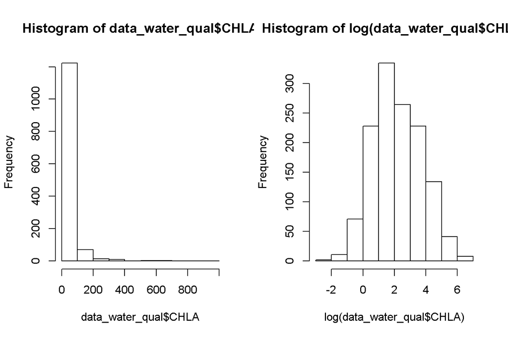

```r
par(mfrow=c(1,2))
hist(data_water_qual$CHLA)
hist(log(data_water_qual$CHLA))
```

```r
summary(data_water_qual$CHLA)
```

```
##    Min. 1st Qu.  Median    Mean 3rd Qu.    Max.    NA's
##   0.067   2.867   7.700  30.120  26.350 936.000       5
```

It looks like there are some pretty extreme values of **chlorophyll *a***.

# Merge data frames

Now we’re going to combine all of those data sets into one. First, we need to make a unique identifier for the lake and survey date.

```r
data_water_qual$ID <- paste(data_water_qual$SITE_ID, data_water_qual$DATE_COL, sep="_")
data_lake_info$ID <- paste(data_lake_info$SITE_ID, data_lake_info$DATE_COL, sep="_")
data_profile$ID <- paste(data_profile$SITE_ID, data_profile$DATE_PROFILE, sep="_")
```

If you inspected `data_profile` closer, you would notice that it has an observation for every depth so let’s subset to just get the surface measurements. This way we have just a single observation of dissolved oxygen and temperature for each lake.

```r
data_profile <- subset(data_profile, data_profile$DEPTH ==0)
```

Now, let’s merge data frames based on the column `ID`.

```r
data_merge <- merge(data_water_qual, data_lake_info, by=c("ID")) # merge the first two
data_merge <- merge(data_merge, data_profile, by=c("ID")) # then merge the result to the third
```

Let’s see how many observations we end up with:

```r
dim(data_merge)
```

```
## [1] 1253  271
```

# Clean up a few things

Remove any observations that are missing CHLA

```r
data_merge <- data_merge[!rowSums(is.na(data_merge["CHLA"])), ]
```

Determine the Julian day of the year. `strftime()` is a function to convert date formats. We want to go from *month/day/year* to the *day of the year*, this way it can be a neat and tidy predictor in our model.

```r
data_merge$DATE <- strftime(as.Date(data_merge$DATE_COL.x, "%m/%d/%Y"), format = "%j")
data_merge$DATE <- as.numeric(data_merge$DATE)
```

# Split data into training and testing sets

We’re going to train the model on a portion of the data and then test it on the remainder. Use the `createDataPartition()` function the package `caret`. Use the argument `p` to Split the data into 75% of the observations for training the model and the rest for testing.

```r
library(caret)
inTrain <- createDataPartition(y=data_merge$CHLA, p=0.75, list=FALSE) # use 75% of data to train to the model
training <- data_merge[inTrain,]
testing <- data_merge[-inTrain,]
```

# Plotting univariate relationships

Before we get into a more complicated analyis let’s check out some of the relationships between each of the single predictors and **chlorophyll *a***.

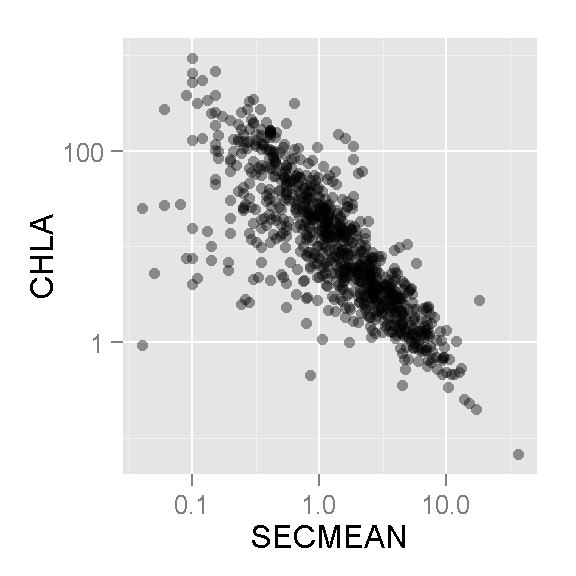

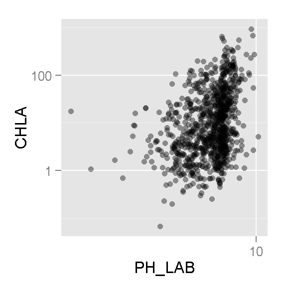

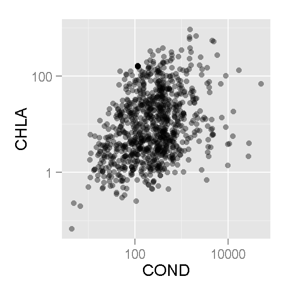

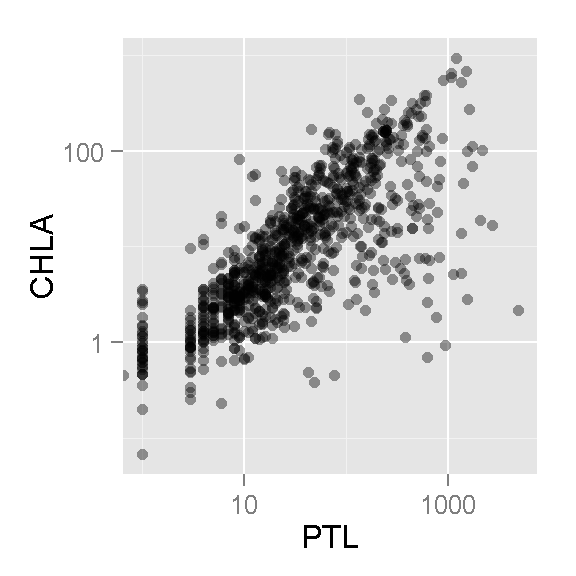

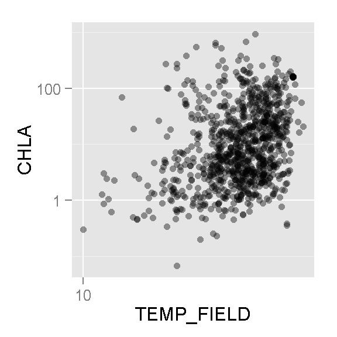

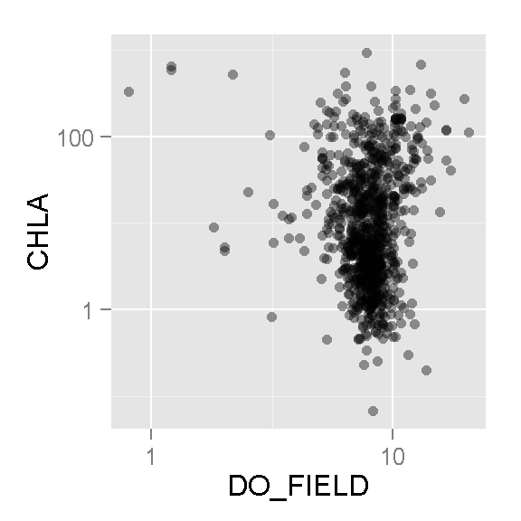

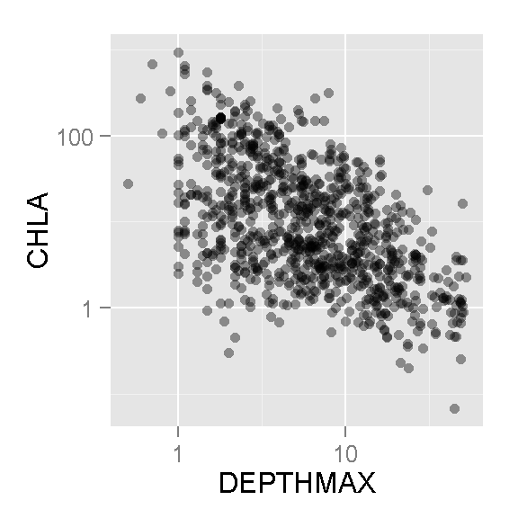

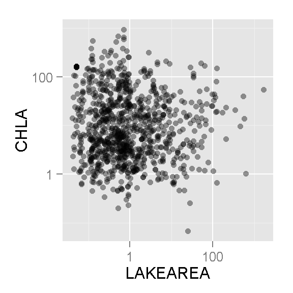

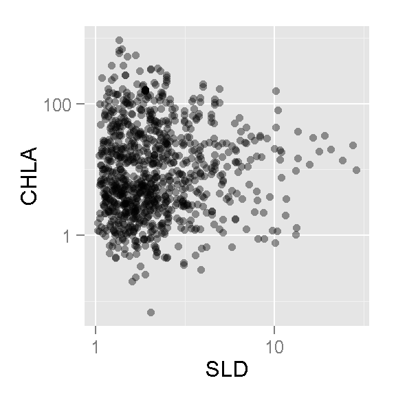

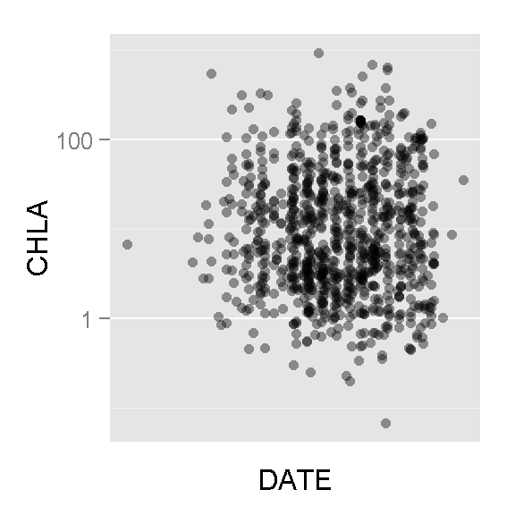

```r
library(ggplot2)

predict_vars <- c("SECMEAN","PH_LAB","COND","PTL","TEMP_FIELD","DO_FIELD","DEPTHMAX","LAKEAREA","SLD","DATE")

for(i in unique(predict_vars)){
  plots <- ggplot(training,aes_string(y="CHLA",x=i)) + geom_point(alpha=0.4)
  plots <- plots + scale_x_log10() + scale_y_log10()
  print(plots)
}
```

It looks like some of the predictors have a pretty linear relationship with **chlorophyll *a***. Those will probably be good predictors.

# Fit a random forest

Now we’re actually going to fit a Random Forest. We’ll use the package `caret` again. `caret` is a nice wrapper package for many machine learning techniques. There are lots of othe packages for random forests and `caret` will actually call `randomForest` directly.

```r
library(caret)

set.seed(12321)

modFit_RF <- train(CHLA ~ SECMEAN + PH_LAB + COND + PTL + TEMP_FIELD + DO_FIELD + DEPTHMAX +
                     LAKEAREA + SLD + DATE,
                   method="rf",
                   data=training)
finMod_RF <- modFit_RF$finalModel
print(modFit_RF)
```

```
## Random Forest
##
## 938 samples
## 271 predictors
##
## No pre-processing
## Resampling: Bootstrapped (25 reps)
##
## Summary of sample sizes: 796, 796, 796, 796, 796, 796, ...
##
## Resampling results across tuning parameters:
##
##   mtry  RMSE      Rsquared   RMSE SD   Rsquared SD
##    2    50.16597  0.4863419  7.309665  0.07835014
##    6    51.97098  0.4649119  8.577039  0.09171927
##   10    53.88646  0.4407646  9.955544  0.10027201
##
## RMSE was used to select the optimal model using  the smallest value.
## The final value used for the model was mtry = 2.
```

We just tuned the model to pick the optimal parametr for `mtry` which is the number of variables randomly sampled to use at each split in the tree. We did this by bootstraping our data (i.e., resampling with replacement), trying different values for `mtry`, and finding the optimal value by minimizing the RMSE (root mean square error, a measure of accuracy).

Let’s look at the results from the final model:

```r
print(finMod_RF)
```

```
##
## Call:
##  randomForest(x = x, y = y, mtry = param$mtry)
##                Type of random forest: regression
##                      Number of trees: 500
## No. of variables tried at each split: 2
##
##           Mean of squared residuals: 2752.641
##                     % Var explained: 49.4
```

And here are the most important variables:

```r
finMod_RF$importance
```

```
##            IncNodePurity
## SECMEAN         852799.6
## PH_LAB          575740.0
## COND            330057.5
## PTL             742659.3
## TEMP_FIELD      193974.2
## DO_FIELD        416656.7
## DEPTHMAX        426489.1
## LAKEAREA        169784.4
## SLD             176705.3
## DATE            158692.6
```

# Observed vs. predicted chlorophyll a

Let’s see how well the Random Forest did. First, we need to remove the test cases that have missing predictors

```r
cols <- c("SECMEAN","PH_LAB","COND","PTL","TEMP_FIELD","DO_FIELD","DEPTHMAX","LAKEAREA","SLD","DATE")
testing <- testing[!rowSums(is.na(testing[cols])), ]
```

Make predictions and add them to to the testing data frame

```r
testing$pred_RF <- predict(modFit_RF, testing)
```

```r
sqrt(sum((testing$pred_RF - testing$CHLA)^2))
```

```
## [1] 744.3662
```

**Plot it**

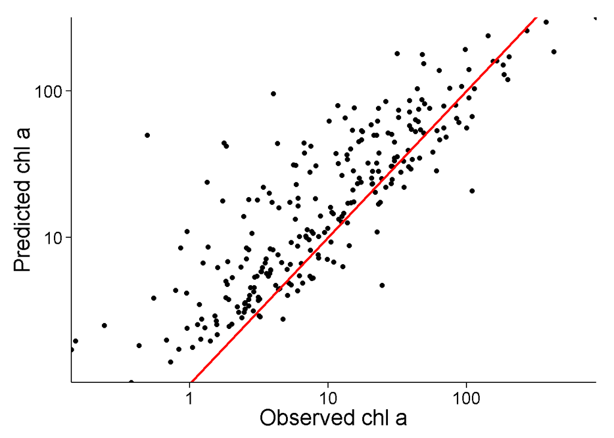

```r
plot_RF_log <- ggplot(testing, aes(x=CHLA, y=pred_RF)) + geom_point(size=2)
plot_RF_log <- plot_RF_log + geom_abline(slope=1,intercept=0,size=1,colour="red")
plot_RF_log <- plot_RF_log + xlab("Observed chl a") + ylab("Predicted chl a")
plot_RF_log <- plot_RF_log + theme_classic(base_size=18)
plot_RF_log <- plot_RF_log + expand_limits(x=0, y=0)
plot_RF_log <- plot_RF_log + scale_x_log10(expand=c(0,0)) + scale_y_log10(expand=c(0,0))
plot_RF_log
```

Not bad. Not great. Most observations are along the 1:1 line in red which would mean the predictions match the observations. Notice, there definitely are some cases where our predictions are way off from observed values. It also looks like there is a tendency for the random forest to predict values that are **higher** than observed.

# Parallel Processing

While this data set is not huge (>1000 observations), fitting Random Forests on large data sets can be slow. Therefore, it’s often helpful to fit your model using all of the cores on your machine (by default R will only use one core).

There are several packages which allow for parallel processing in R. These include `doSNOW`, `doMC`, `foreach`, and many others. For this example, I will use `doSNOW`.

```r
library(caret)
library(doSNOW)

cl <- makeCluster(4, type="SOCK") # set-up the cluster
registerDoSNOW(cl)

# fit the model
modFit_RF_par <- train(CHLA ~ SECMEAN + PH_LAB + COND + PTL + TEMP_FIELD + DO_FIELD +
                         DEPTHMAX + LAKEAREA + SLD + DATE,
                   method="rf",
                   data=training)

stopCluster(cl)
```

# Even bigger data

While 1200 or so observations might be pretty big for ecology, data sets can get a lot bigger! `R` doesn’t necessarily do a great job at dealing with huge data sets (e.g., 100,000s of rows). Two common packages used to jump this hurdle are `bigmemory` and `ff`. They both allow large datasets to be stored on the disk, rather than in RAM.

Here’s what it would look like if you wanted to repeat the data inport step with `ff`:

```r
library(ff)

URL <- "http://water.epa.gov/type/lakes/assessmonitor/lakessurvey/upload/NLA2007_WaterQuality_20091123.csv"
X <- getURL(URL, ssl.verifypeer = FALSE)
data_water_qual <- read.table.ffdf(file=textConnection(X), FUN="read.csv")
```